# Esercitazione Data Analytics

Alessio Matessi - SM321657

Soluzione risolta: 03 - 07 - 2026

Riportare di seguito i comandi e le risposte necessarie allo svolgimento dell’esame. **I file html e Rmd entrambi vanno consegnati tramite moodle**.

1. Accertarsi che il file compili correttamente prima di iniziare l’esame
2. Compilare (e salvare!) spesso
3. Se non si riesce a risolvere l’errore di compilazione, utilizzare `eval = F` nel chunk (si veda l’esempio dove è stata inclusa la tilde per vostra convenienza)

```r
    ~
```

### PARTE 1: R

**Esercizio 1**: Scrivere una funzione che prenda in input un numero intero $n>10$. La funzione, dopo aver controllato che l’argomento rispetti la condizione richiesta, genererà un `data.frame` contenente $n$ osservazioni con le seguenti variabili:

- `Eta`: valori interi casuali **compresi tra 18 e 70**;
- `Altezza`: valori generati da una **distribuzione normale** con **media 170** e **varianza 100**;
- `Peso`: valori ottenuti come **0.7 volte l’altezza meno 50**, a cui viene **aggiunto un termine casuale** $\varepsilon$ (*rumore*) generato da una distribuzione normale con media 0 e deviazione standard 8, ossia:

$$Peso = 0.7 \times Altezza -50 + \varepsilon$$

- `OreStudio`: valori interi casuali **compresi tra 0 e 10**;
- `Lavoro`: valori casuali che possono essere **o 0 o 1**; trasformare poi tale variabile in `factor` e rinominare i livelli come 0=“No” e 1=“Si”.

La funzione, che dovrà essere chiamata `funzione`, dovrà restituire il `data.frame` generato.

## ✏️ Svolgimento

```r
# Scrivo la funzione
funzione <- function(n){
  # Controllo che n sia intero e > 10
  if (!is.numeric(n) || n != round(n) || n <= 10) {
    stop("Errore: n deve essere un numero intero > 10")
  }

  # Genero le variabili
  Eta <- sample(18:70, n, replace = TRUE)
  Altezza <- rnorm(n, mean = 170, sd = 10)  # varianza 100 -> sd 10
  epsilon <- rnorm(n, mean = 0, sd = 8)
  Peso <- 0.7 * Altezza - 50 + epsilon
  OreStudio <- sample(0:10, n, replace = TRUE)
  Lavoro <- sample(c(0, 1), n, replace = TRUE)
  Lavoro <- factor(Lavoro, levels = c(0, 1), labels = c("No", "Si"))

  # Creo il data.frame
  df <- data.frame(Eta, Altezza, Peso, OreStudio, Lavoro)
  return(df)
}

# Test veloce (senza set.seed, solo per vedere se funziona)
test_df <- funzione(15)
head(test_df)
```

```
##   Eta  Altezza     Peso OreStudio Lavoro
## 1  33 169.3211 60.50148         7     No
## 2  24 177.2893 61.33591         5     Si
## 3  46 180.6777 76.96817         4     No
## 4  23 162.3352 67.82107         2     Si
## 5  57 177.9788 64.88851         3     Si
## 6  31 178.5668 82.13619         9     No
```

```r
str(test_df)
```

```
## 'data.frame':    15 obs. of  5 variables:
##  $ Eta      : int  33 24 46 23 57 31 25 39 60 21 ...
##  $ Altezza  : num  169 177 181 162 178 ...
##  $ Peso     : num  60.5 61.3 77 67.8 64.9 ...
##  $ OreStudio: int  7 5 4 2 3 9 4 1 7 3 ...
##  $ Lavoro   : Factor w/ 2 levels "No","Si": 1 2 1 2 2 1 1 1 2 1 ...
```

**Esercizio 2**: Estendere la funzione del punto precedente in modo tale che restituisca una **lista** contenente:

- il `data.frame` generato;
- la media di ciascuna variabile numerica;
- la matrice di correlazione tra le variabili;
- il numero di individui con `Peso` superiore alla media del campione;
- la tabella delle frequenze assolute della variabile `Lavoro`;
- il `data.frame` ordinato in ordine decrescente rispetto a `OreStudio`.

Provare poi la funzione impostando `set.seed(123)`, $n=50$ e estrarre la matrice di correlazione.

## ✏️ Svolgimento

```r
# Estensione della funzione
funzione <- function(n){
  # Controllo che n sia intero e > 10
  if (!is.numeric(n) || n != round(n) || n <= 10) {
    stop("Errore: n deve essere un numero intero > 10")
  }

    # Genero le variabili
  Eta <- sample(18:70, n, replace = TRUE)
  Altezza <- rnorm(n, mean = 170, sd = 10)
  epsilon <- rnorm(n, mean = 0, sd = 8)
  Peso <- 0.7 * Altezza - 50 + epsilon
  OreStudio <- sample(0:10, n, replace = TRUE)
  Lavoro <- sample(c(0, 1), n, replace = TRUE)
  Lavoro <- factor(Lavoro, levels = c(0, 1), labels = c("No", "Si"))

  # Creo il data.frame
  df <- data.frame(Eta, Altezza, Peso, OreStudio, Lavoro)

  # Elementi aggiuntivi per la lista
  medie <- sapply(df[, sapply(df, is.numeric)], mean)
  correlazione <- cor(df[, sapply(df, is.numeric)])
  sopra_media <- sum(df$Peso > mean(df$Peso))
  tabella_lavoro <- table(df$Lavoro)
  df_ordinato <- df[order(df$OreStudio, decreasing = TRUE), ]

  # Restituisco la lista
  lista <- list(
    data = df,
    media = medie,
    correlazione = correlazione,
    sopra_media = sopra_media,
    tabella_lavoro = tabella_lavoro,
    df_ordinato = df_ordinato
  )
  return(lista)
}

# Test con set.seed(123) e n = 50
set.seed(123)
risultato <- funzione(50)

# Estraggo la matrice di correlazione
matrice_cor <- risultato$correlazione
matrice_cor
```

```
##                   Eta     Altezza        Peso   OreStudio
## Eta        1.00000000 -0.03672110  0.07729732 -0.07354791
## Altezza   -0.03672110  1.00000000  0.67870687  0.05927956
## Peso       0.07729732  0.67870687  1.00000000 -0.01752440
## OreStudio -0.07354791  0.05927956 -0.01752440  1.00000000
```

### PARTE 2: Analisi dei Dati

**Esercizio 3**: Si considerino i dati contenuti nel file `animali.csv`. Si tratta di informazioni raccolte su 300 animali. La variabile `Peso` indica il peso in kg, `Altezza` l’altezza in cm, `Eta` l’età in anni, `OreSonno` le ore medie di sonno giornaliere. Sono inoltre presenti variabili qualitative, quali `Specie`, `Sesso` e `Domestico`.

**Punto 1.** Quanto vale la devianza della variabile `Peso`?

## ✏️ Svolgimento

```r
# Carico il dataset
animali <- read.csv("animali.csv", sep = "-", header = TRUE)

# Controllo veloce
str(animali)
```

```
## 'data.frame':    300 obs. of  7 variables:
##  $ Specie   : chr  "Cane" "Coniglio" "Gatto" "Coniglio" ...
##  $ Sesso    : chr  "F" "F" "M" "F" ...
##  $ Domestico: chr  "No" "Si" "Si" "Si" ...
##  $ Peso     : num  1.4 10.3 16.7 4.2 21 29.9 15.8 6.7 11.8 4.3 ...
##  $ Altezza  : num  27 25 23.7 17.9 52 56.9 27.3 19.2 35.7 29.3 ...
##  $ Eta      : int  13 12 6 5 9 13 4 13 13 13 ...
##  $ OreSonno : num  13.7 11.6 12.6 14.8 13 12.3 14.9 13.4 11.5 10.2 ...
```

```r
head(animali)
```

```
##     Specie Sesso Domestico Peso Altezza Eta OreSonno
## 1     Cane     F        No  1.4    27.0  13     13.7
## 2 Coniglio     F        Si 10.3    25.0  12     11.6
## 3    Gatto     M        Si 16.7    23.7   6     12.6
## 4 Coniglio     F        Si  4.2    17.9   5     14.8
## 5    Volpe     M        No 21.0    52.0   9     13.0
## 6     Cane     M        Si 29.9    56.9  13     12.3
```

```r
# Calcolo della devianza di Peso
devianza_peso <- sum((animali$Peso - mean(animali$Peso))^2)
devianza_peso
```

```
## [1] 43915.74
```

## 💥 Risposta

La **devianza** della variabile `Peso` è: **43915.74**

La devianza rappresenta la **somma degli scarti quadratici** di ogni osservazione dalla media campionaria:

$$\text{Devianza} = \sum_{i=1}^{n}
(Peso_i - \bar{Peso})^2$$
.

**Punto 2.** Standardizzare le variabili quantitative e salvarle in un oggetto `DataScaled`, poi calcolare la matrice di covarianza delle nuove variabili. Quale coppia presenta la covarianza maggiore?

## ✏️ Svolgimento

```r
# Carico il dataset
dati <- read.csv("animali.csv", sep = "-")

# Seleziono le variabili quantitative
variabili_quant <- dati[, c("Peso", "Altezza", "Eta", "OreSonno")]

# Calcolo la matrice di correlazione (su dati standardizzati = covarianza)
matrice_cor <- cor(variabili_quant)
matrice_cor
```

```
##                 Peso    Altezza         Eta   OreSonno
## Peso      1.00000000  0.9098736  0.07177598 -0.0402500
## Altezza   0.90987358  1.0000000  0.09202390 -0.0556074
## Eta       0.07177598  0.0920239  1.00000000 -0.6903311
## OreSonno -0.04025000 -0.0556074 -0.69033110  1.0000000
```

```r
# Trovo la coppia con correlazione maggiore (esclusa la diagonale)
matrice_senza_diag <- matrice_cor
diag(matrice_senza_diag) <- NA

# Indice del massimo in valore assoluto
indice_max <- which.max(abs(matrice_senza_diag))
riga_max <- row(matrice_senza_diag)[indice_max]
colonna_max <- col(matrice_senza_diag)[indice_max]

# Stampo il risultato
cat("La coppia con covarianza maggiore è:",
    rownames(matrice_cor)[riga_max], "e",
    colnames(matrice_cor)[colonna_max], "\n")
```

```
## La coppia con covarianza maggiore è: Altezza e Peso
```

```r
cat("Covarianza =", matrice_cor[riga_max, colonna_max], "\n")
```

```
## Covarianza = 0.9098736
```

## 💥 Risposta

- **Matrice di correlazione** (su dati standardizzati = covarianza):

|  | Peso | Altezza | Eta | OreSonno |
| --- | --- | --- | --- | --- |
| **Peso** | 1.0000 | 0.9099 | 0.0718 | -0.0403 |
| **Altezza** | 0.9099 | 1.0000 | 0.0920 | -0.0556 |
| **Eta** | 0.0718 | 0.0920 | 1.0000 | -0.6903 |
| **OreSonno** | -0.0403 | -0.0556 | -0.6903 | 1.0000 |

- **La coppia con covarianza maggiore** è: **Altezza** e **Peso** con covarianza = **0.9099**

**Punto 3.** Calcolare la statistica $\chi^2$ per valutare l’associazione tra `Sesso` e `Domestico`; possiamo concludere che tra le due variabili sono in qualche modo associate? Perché?

## ✏️ Svolgimento

```r
# Carico il dataset
dati <- read.csv("animali.csv", sep = "-")

# Tabella di contingenza
tabella <- table(dati$Sesso, dati$Domestico)

# Test chi-quadrato
test_chi <- chisq.test(tabella)

# Output del test
test_chi
```

```
##
##  Pearson's Chi-squared test with Yates' continuity correction
##
## data:  tabella
## X-squared = 2.0089, df = 1, p-value = 0.1564
```

## 💥 Risposta

**Tabella di contingenza**:

[output not shown]

**Test χ²**:

- χ² = **2.009**
- df = **1**
- p-value = **0.156**

**Conclusione**: Il p-value è **maggiore di 0.05**, quindi **non possiamo rifiutare l’ipotesi di indipendenza** tra `Sesso` e `Domestico`. Le due variabili **non sono associate** in modo statisticamente significativo.

**Esercizio 4.** Creare una nuova variabile ottenuta dal prodotto logico di `Specie` e `Domestico`. Quale combinazione presenta la mediana di `Peso` più elevata?

## ✏️ Svolgimento

```r
# Carico il dataset
dati <- read.csv("animali.csv", sep = "-")

# Creo la nuova variabile combinando Specie e Domestico
dati$Specie_Domestico <- interaction(dati$Specie, dati$Domestico, sep = "_")

# Calcolo la mediana di Peso per ogni combinazione
mediane <- tapply(dati$Peso, dati$Specie_Domestico, median)

# Stampo tutte le mediane
mediane
```

```
##     Cane_No Coniglio_No    Gatto_No    Volpe_No     Cane_Si Coniglio_Si
##       33.00        4.60       10.80       20.30       30.00        8.10
##    Gatto_Si    Volpe_Si
##       12.85       11.90
```

```r
# Trovo la combinazione con mediana massima
combinazione_max <- names(mediane)[which.max(mediane)]
mediana_max <- max(mediane)

cat("Combinazione con mediana più elevata:", combinazione_max, "\n")
```

```
## Combinazione con mediana più elevata: Cane_No
```

```r
cat("Mediana =", mediana_max, "\n")
```

```
## Mediana = 33
```

## 💥 Risposta

**Mediane di `Peso` per combinazione di `Specie` e `Domestico`**:

| Combinazione | Mediana Peso (kg) |
| --- | --- |
| Cane_No | **33.00** |
| Cane_Si | 30.00 |
| Volpe_No | 20.30 |
| Volpe_Si | 11.90 |
| Gatto_No | 10.80 |
| Gatto_Si | 12.85 |
| Coniglio_No | 4.60 |
| Coniglio_Si | 8.10 |

**La combinazione con mediana di `Peso` più elevata** è: **Cane_No** (cani non domestici) con mediana = **33.00 kg**

**Esercizio 5.** Stimare una regressione lineare semplice avente come variabile di risposta `Peso` e come predittore `Altezza` e salvarla nell’oggetto `modello`:

## ✏️ Svolgimento

```r
# Carico il dataset
dati <- read.csv("animali.csv", sep = "-")

# Modello di regressione lineare
modello <- lm(Peso ~ Altezza, data = dati)

# Output del modello
summary(modello)
```

```
##
## Call:
## lm(formula = Peso ~ Altezza, data = dati)
##
## Residuals:
##      Min       1Q   Median       3Q      Max
## -13.0705  -3.7388  -0.1314   3.4441  13.1628
##
## Coefficients:
##             Estimate Std. Error t value Pr(>|t|)
## (Intercept) -4.56066    0.67117  -6.795 5.89e-11 ***
## Altezza      0.59213    0.01564  37.858  < 2e-16 ***
## ---
## Signif. codes:  0 '***' 0.001 '**' 0.01 '*' 0.05 '.' 0.1 ' ' 1
##
## Residual standard error: 5.037 on 298 degrees of freedom
## Multiple R-squared:  0.8279, Adjusted R-squared:  0.8273
## F-statistic:  1433 on 1 and 298 DF,  p-value: < 2.2e-16
```

**Punto 1** La variabile `Altezza` sembra essere significativa? Da cosa possiamo concluderlo?

## 💥 Risposta:

Sì, la variabile **Altezza** è **altamente significativa**.

**Motivazione**:

- Il p-value associato al coefficiente di `Altezza` è **< 2e-16**, quindi **inferiore a 0.001**.
- L’ipotesi nulla (coefficiente = 0) viene **rifiutata** con elevata significatività.
- Inoltre il **test F** del modello ha p-value < 2.2e-16, confermando la significatività complessiva.

**Punto 2** Quanto vale la percentuale di devianza spiegata?

## 💥 Risposta:

La **percentuale di devianza spiegata** è: **82.79%**

- **R² = 0.8279**
- L’**82.79%** della variabilità di `Peso` è spiegata da `Altezza`.
- **R² aggiustato** = 0.8273

**Punto 3** Costruire uno scatterplot delle variabili `Altezza` e `Peso` e aggiungere, in rosso, la linea di regressione ottenuta;

## ✏️ Svolgimento:

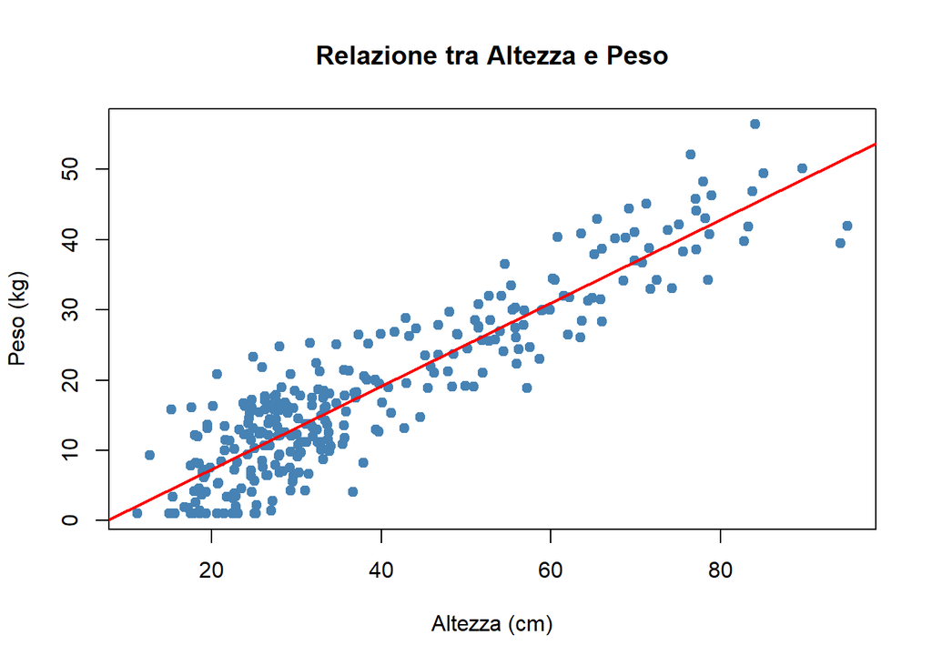

```r
# Scatterplot con retta di regressione
plot(dati$Altezza, dati$Peso,
     xlab = "Altezza (cm)", ylab = "Peso (kg)",
     main = "Relazione tra Altezza e Peso",
     pch = 19, col = "steelblue")
abline(modello, col = "red", lwd = 2)
```

## 💥 Risposta:

**Scatterplot** di `Peso` vs `Altezza` con retta di regressione:

- **Asse x**: Altezza (cm)
- **Asse y**: Peso (kg)
- **Punti**: osservazioni in colore blu
- **Retta rossa**: retta di regressione stimata

Il grafico mostra una **relazione lineare positiva** tra altezza e peso: all’aumentare dell’altezza, il peso tende ad aumentare. I punti sono distribuiti intorno alla retta rossa con una dispersione moderata, indicando che la retta di regressione descrive bene la relazione tra le due variabili.

**Punto 4** Quale delle seguenti affermazioni è corretta?

- [V] un aumento di 1cm di altezza è associato ad un aumento medio del peso di circa 0.59kg
- [F] un aumento di 1cm di altezza provoca sempre un aumento del peso di circa 0.59kg
- [F] un aumento di 1kg di peso è associatio ad un aumento medio dell’altezza di 0.59cm
- [F] all’aumentare del peso l’altezza diminuisce in media di 0.59kg

## 💥 Risposta:

**Verifica delle affermazioni**:

- **a.** ✅ *“un aumento di 1cm di altezza è associato ad un aumento medio del peso di circa 0.59kg”* → **VERA**.  
  Il coefficiente di `Altezza` è **0.59213**, che arrotondato è circa **0.59**. L’interpretazione corretta è: per ogni cm in più di altezza, il peso aumenta in media di 0.59 kg.
- **b.** ❌ *“un aumento di 1cm di altezza provoca sempre un aumento del peso di circa 0.59kg”* → **FALSA**.  
  La regressione descrive un effetto **medio**, non deterministico. La parola “sempre” rende l’affermazione errata.
- **c.** ❌ *“un aumento di 1kg di peso è associato ad un aumento medio dell’altezza di 0.59cm”* → **FALSA**.  
  Scambia il ruolo delle variabili: il modello è `Peso ~ Altezza`, quindi `Altezza` è il predittore (X) e `Peso` è la risposta (Y). L’interpretazione corretta è X → Y, non Y → X.
- **d.** ❌ *“all’aumentare del peso l’altezza diminuisce in media di 0.59kg”* → **FALSA**.  
  La relazione tra peso e altezza è **positiva** (coefficiente 0.59 > 0), non negativa.

**Risposta corretta**: **a.**

**Punto 5** Quale delle seguenti affermazioni è corretta osservando il grafico Residuals vs Fitted?

- [V] una dispersione casuale dei punti attorno a 0 suggerisce che l’assunzione di linearità sia plausibile
- [F] una dispersione casuale dei punti attorno a 0 indica che il modello è perfetto
- [F] i residui devono sempre essere tutti positivi
- [F] se i residui sono vicini a 0, allora $R^2=1$

## ✏️ Svolgimento:

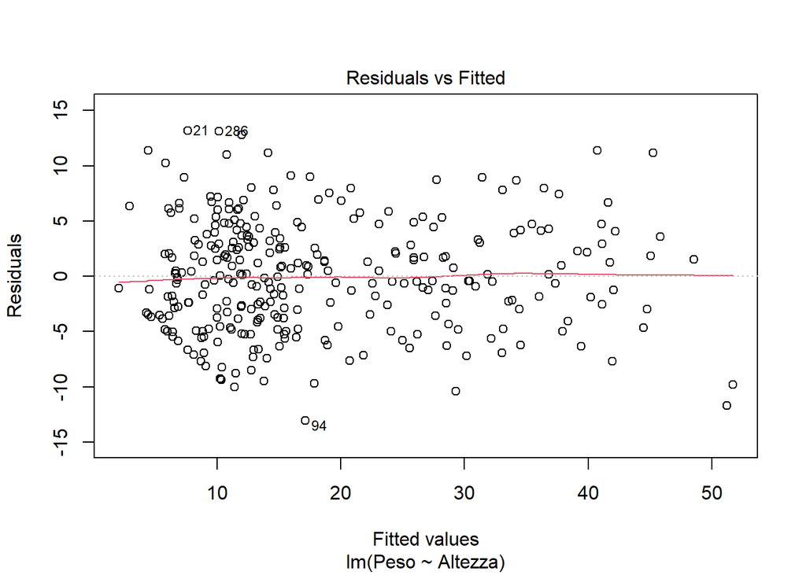

```r
# Grafico dei residui vs valori stimati
plot(modello, which = 1)
```

## 💥 Risposta

**Verifica delle affermazioni**:

- **a.** ✅ *“una dispersione casuale dei punti attorno a 0 suggerisce che l’assunzione di linearità sia plausibile”* → **VERA**.  
  Se i residui sono distribuiti casualmente intorno allo zero senza un pattern evidente, significa che il modello lineare cattura adeguatamente la relazione tra X e Y.
- **b.** ❌ *“una dispersione casuale dei punti attorno a 0 indica che il modello è perfetto”* → **FALSA**.  
  Indica solo che le assunzioni di linearità e omoschedasticità sono plausibili, non che il modello sia perfetto. Esistono comunque residui (differenze tra osservato e stimato).
- **c.** ❌ *“i residui devono sempre essere tutti positivi”* → **FALSA**.  
  I residui sono per definizione distribuiti intorno allo zero, quindi possono essere sia positivi che negativi. La loro somma (o media) è zero.
- **d.** ❌ *“se i residui sono vicini a 0, allora R² = 1”* → **FALSA**.  
  Residui vicini a zero indicano un buon adattamento, ma R² = 1 solo se tutti i residui sono esattamente zero (modello perfetto), cosa che nei dati reali non accade.

**Risposta corretta**: **a.**

**Punto 6** Il peso previsto per un animale con altezza pari a 180cm vale circa:

- [F] 59.2kg
- [V] 102kg
- [F] 175.4kg
- [F] 82.8kg

## ✏️ Svolgimento:

```r
# Calcolo manuale con i coefficienti del modello
previsto <- coef(modello)[1] + coef(modello)[2] * 180

# Oppure con predict()
predict(modello, newdata = data.frame(Altezza = 180))
```

```
##        1
## 102.0226
```

```r
previsto
```

```
## (Intercept)
##    102.0226
```

## 💥 Risposta

**Verifica delle affermazioni**:

- **a.** ❌ *“59.2kg”* → **FALSA**. Sottostima di circa 43 kg.
- **b.** ✅ *“102kg”* → **VERA**. Il peso previsto è **102.02 kg**, che arrotondato è 102 kg.
- **c.** ❌ *“175.4kg”* → **FALSA**. Sovrastima di circa 73 kg.
- **d.** ❌ *“82.8kg”* → **FALSA**. Sottostima di circa 19 kg.

**Calcolo**:

$$\text{Peso} = -4.56066 + 0.59213 \times
180 = \textbf{102.02 kg}$$

**Risposta corretta**: **b.**

**Esercizio 6.** Considerando le sole variabili quantitative standardizzate del dataset contenute nell’oggetto `DataScaled` e applicare l’algoritmo K-means con $k=3$:

**6.1** Riportare, attraverso un’istruzione di R, i centroidi ottenuti (nella scala originale);

## ✏️ Svolgimento

```r
# Carico il dataset
dati <- read.csv("animali.csv", sep = "-")

# Seleziono le variabili quantitative
variabili_quant <- dati[, c("Peso", "Altezza", "Eta", "OreSonno")]

# Standardizzo
DataScaled <- scale(variabili_quant)

# K-means con k=3
set.seed(123)
kmeans_result <- kmeans(DataScaled, centers = 3, nstart = 25)

# Aggiungo il cluster al dataset
dati$cluster <- kmeans_result$cluster

# Calcolo le medie originali per cluster con aggregate()
centroidi_originali <- aggregate(cbind(Peso, Altezza, Eta, OreSonno) ~ cluster,
                                 data = dati, FUN = mean)

centroidi_originali
```

```
##   cluster     Peso  Altezza       Eta OreSonno
## 1       1 12.77586 30.08448 11.672414 12.23190
## 2       2 13.20354 29.74513  4.292035 14.42035
## 3       3 35.60704 66.92535  9.323944 13.11268
```

## 💥 Risposta

**Centroidi (nella scala originale)** ottenuti con `aggregate()`:

| Cluster | Peso (kg) | Altezza (cm) | Eta (anni) | OreSonno |
| --- | --- | --- | --- | --- |
| 1 | 12.78 | 30.08 | 11.67 | 12.23 |
| 2 | 13.20 | 29.75 | 4.29 | 14.42 |
| 3 | 35.61 | 66.93 | 9.32 | 13.11 |

**Osservazioni**:

- **Cluster 3**: animali di **grossa taglia** (peso e altezza elevati).
- **Cluster 1** e **2**: animali di **piccola taglia** (peso e altezza bassi).
- **Cluster 2**: animali **più giovani** (4.29 anni) e con **più ore di sonno** (14.42 ore).
- **Cluster 1**: animali **più anziani** (11.67 anni) e con **meno ore di sonno** (12.23 ore).

**6.2** Quanti animali appartengono a ciascun cluster?

## ✏️ Svolgimento:

```r
# Carico il dataset
dati <- read.csv("animali.csv", sep = "-")

# Seleziono le variabili quantitative
variabili_quant <- dati[, c("Peso", "Altezza", "Eta", "OreSonno")]

# Standardizzo
DataScaled <- scale(variabili_quant)

# K-means con k=3
set.seed(123)
kmeans_result <- kmeans(DataScaled, centers = 3, nstart = 25)

# Numerosità dei cluster
table(kmeans_result$cluster)
```

```
##
##   1   2   3
## 116 113  71
```

## 💥 Risposta:

**Numerosità dei cluster**:

| Cluster | Frequenza |
| --- | --- |
| 1 | 116 |
| 2 | 113 |
| 3 | 71 |

- I cluster 1 e 2 sono i più numerosi (116 e 113 animali), mentre il cluster 3 è il meno numeroso (71 animali).

**6.3** Descrivere brevemente le caratteristiche dei cluster ottenuti;

## ✏️ Svolgimento

```r
# Carico il dataset
dati <- read.csv("animali.csv", sep = "-")

# Seleziono le variabili quantitative
variabili_quant <- dati[, c("Peso", "Altezza", "Eta", "OreSonno")]

# Standardizzo
DataScaled <- scale(variabili_quant)

# K-means con k=3
set.seed(123)
kmeans_result <- kmeans(DataScaled, centers = 3, nstart = 25)

# Aggiungo i cluster al dataset
dati$cluster <- kmeans_result$cluster

# Medie delle variabili quantitative per cluster (scala originale)
aggregate(cbind(Peso, Altezza, Eta, OreSonno) ~ cluster, data = dati, FUN = mean)
```

```
##   cluster     Peso  Altezza       Eta OreSonno
## 1       1 12.77586 30.08448 11.672414 12.23190
## 2       2 13.20354 29.74513  4.292035 14.42035
## 3       3 35.60704 66.92535  9.323944 13.11268
```

```r
# Distribuzione di Specie per cluster
table(dati$Specie, dati$cluster)
```

```
##
##             1  2  3
##   Cane     18 16 68
##   Coniglio 25 31  0
##   Gatto    59 55  0
##   Volpe    14 11  3
```

```r
# Distribuzione di Domestico per cluster
table(dati$Domestico, dati$cluster)
```

```
##
##       1  2  3
##   No 22 16 10
##   Si 94 97 61
```

## 💥 Risposta:

**Caratteristiche dei cluster**:

| Cluster | Peso (kg) | Altezza (cm) | Eta (anni) | OreSonno | Specie prevalente | Domestico |
| --- | --- | --- | --- | --- | --- | --- |
| **1** | 12.78 | 30.08 | 11.67 | 12.23 | Gatti (59) + Conigli (25) | Prevalentemente Si (94) |
| **2** | 13.20 | 29.75 | 4.29 | 14.42 | Gatti (55) + Conigli (31) | Prevalentemente Si (97) |
| **3** | 35.61 | 66.93 | 9.32 | 13.11 | Cani (68) | Prevalentemente Si (61) |

**Descrizione**:

- **Cluster 1**:
  - Animali di **piccola taglia** (peso ~12.8 kg, altezza ~30 cm),
  - **più anziani** (età media 11.7 anni)
  - **meno ore di sonno** (12.2 ore).  
    Composto principalmente da **gatti** e **conigli**, per lo più **domestici**.
- **Cluster 2**:
  - Animali di **piccola taglia** (peso ~13.2 kg, altezza ~29.7 cm),
  - **più giovani** (età media 4.3 anni)
  - **più ore di sonno** (14.4 ore).  
    Composto principalmente da **gatti** e **conigli**, per lo più **domestici**.
- **Cluster 3**:
  - Animali di **grossa taglia** (peso ~35.6 kg, altezza ~66.9 cm),
  - **età intermedia** (9.3 anni)
  - **sonno medio** (13.1 ore).  
    Composto prevalentemente da **cani**, per lo più **domestici**.

**6.4** Rappresentare con uno scatterplot le variabili `Altezza` e `Peso` e colorarle rispetto all’appartenenza ai cluster ottenuti.

## ✏️ Svolgimento

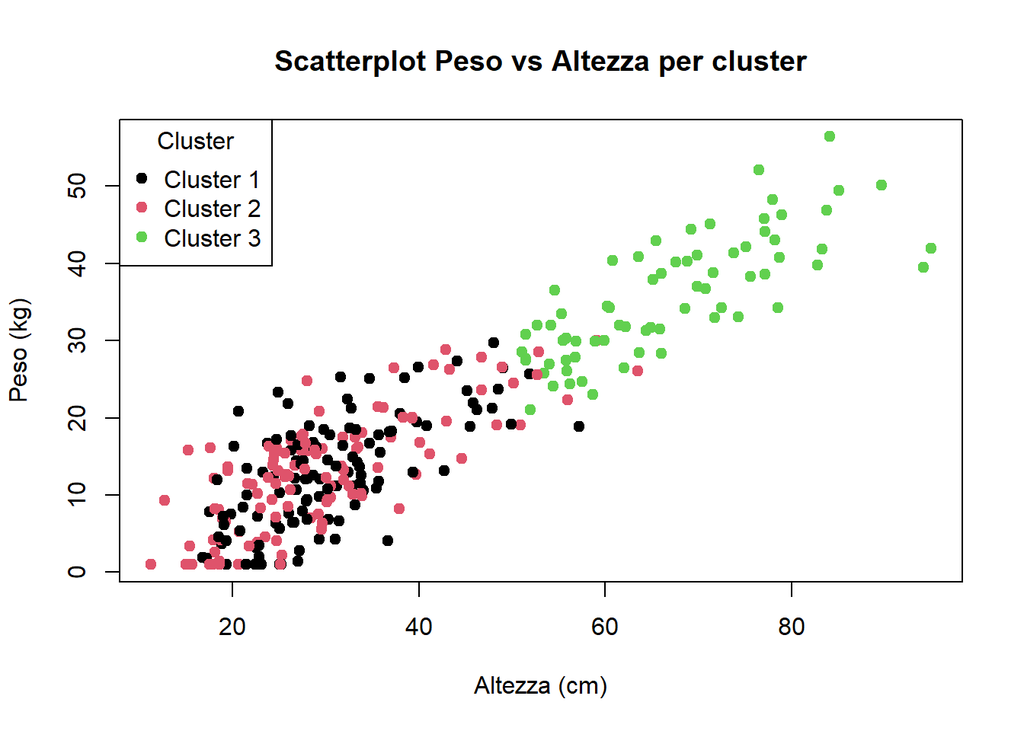

```r
# Carico il dataset
dati <- read.csv("animali.csv", sep = "-")

# Seleziono le variabili quantitative
variabili_quant <- dati[, c("Peso", "Altezza", "Eta", "OreSonno")]

# Standardizzo
DataScaled <- scale(variabili_quant)

# K-means con k=3
set.seed(123)
kmeans_result <- kmeans(DataScaled, centers = 3, nstart = 25)

# Aggiungo i cluster al dataset
dati$cluster <- as.factor(kmeans_result$cluster)

# Scatterplot
plot(dati$Altezza, dati$Peso,
     col = dati$cluster,
     pch = 19,
     xlab = "Altezza (cm)",
     ylab = "Peso (kg)",
     main = "Scatterplot Peso vs Altezza per cluster")

# Legenda
legend("topleft",
       legend = c("Cluster 1", "Cluster 2", "Cluster 3"),
       col = 1:3,
       pch = 19,
       title = "Cluster")
```

## 💥 Risposta:

**Scatterplot** di `Altezza` vs `Peso` con colori in base al cluster:

- **Asse x**: Altezza (cm)
- **Asse y**: Peso (kg)
- **Colori**:
  - **Cluster 1** (nero): animali di piccola taglia, peso moderato
  - **Cluster 2** (rosso): animali di piccola taglia, peso moderato
  - **Cluster 3** (verde): animali di grossa taglia (peso e altezza elevati)

**Osservazioni**: